# Упражнение 8

Людуховский В.В.

10 05 2021

Задания Для каждой модели: 1. Указать настроечные параметры метода из своего варианта (например: количество узлов, количество предикторов, скорость обучения). 2. Подогнать модель на обучающей выборке (50% наблюдений). Рассчитать MSE на тестовой выборке. 3. Перестроить модель с помощью метода, указанного в варианте. 4. Сделать прогноз по модели с подобранными в п.3 параметрами на тестовой выборке, оценить его точность и построить график «прогноз-реализация».

Вариант 18 Данные *Carseats{ISLR}*

Непрерывный Y = *Sales* Объясняющие переменные - все остальные Метод подгонки полей бэггинг

```r
attach(Carseats)
data('Carseats')
detach(Carseats)
```

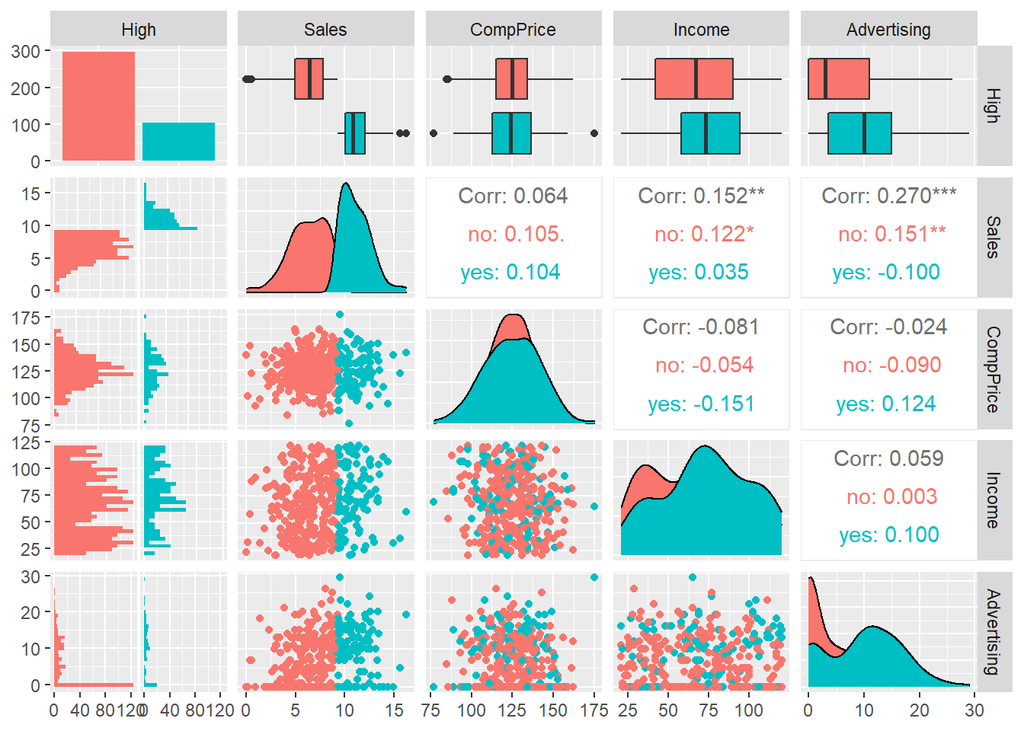

```r
#Новая переменная
High <- ifelse(Carseats$Sales <= 9.3, "no", "yes")
Carseats <- cbind(Carseats, High)
Carseats$High <- as.factor(Carseats$High)
#Матричные графики разброса переменных
p <- ggpairs(Carseats[, c(12, 1:4)], aes(color = High))
suppressMessages(print(p))
```

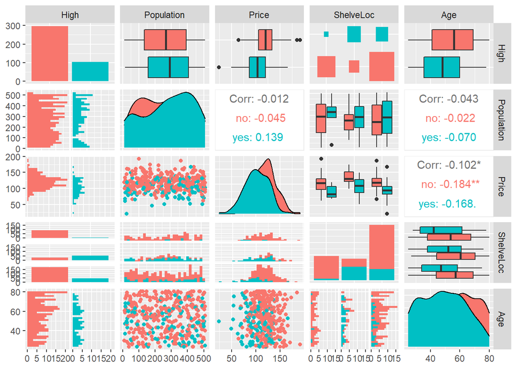

```r
p <- ggpairs(Carseats[, c(12, 5:8)], aes(color = High))
suppressMessages(print(p))
```

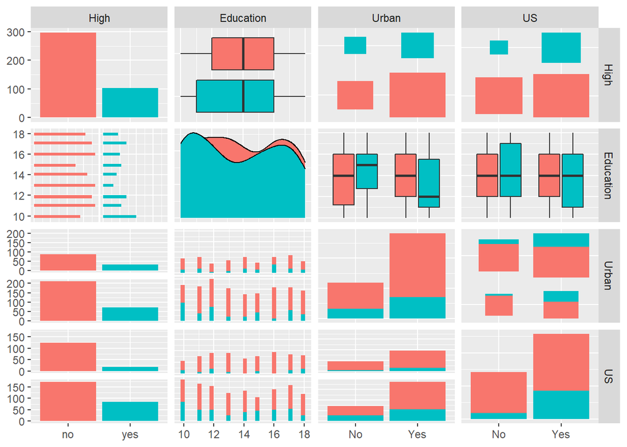

```r
p <- ggpairs(Carseats[, c(12, 9:11)], aes(color = High))
suppressMessages(print(p))
```

```r
tree.carseats2 <- tree(High ~ . -Sales, data = Carseats)
tree.carseats1 <- tree(Sales ~ ., data = Carseats)
summary(tree.carseats1)
```

```
##
## Regression tree:
## tree(formula = Sales ~ ., data = Carseats)
## Variables actually used in tree construction:
## [1] "High"      "ShelveLoc" "Price"     "CompPrice"
## Number of terminal nodes:  8
## Residual mean deviance:  2.363 = 926.2 / 392
## Distribution of residuals:
##     Min.  1st Qu.   Median     Mean  3rd Qu.     Max.
## -5.84100 -1.00200  0.09963  0.00000  1.08600  4.48600
```

```r
summary(tree.carseats2)
```

```
##
## Classification tree:
## tree(formula = High ~ . - Sales, data = Carseats)
## Variables actually used in tree construction:
## [1] "ShelveLoc"   "Price"       "CompPrice"   "Age"         "Advertising"
## [6] "Income"      "Urban"       "Education"
## Number of terminal nodes:  20
## Residual mean deviance:  0.3329 = 126.5 / 380
## Misclassification error rate: 0.06 = 24 / 400
```

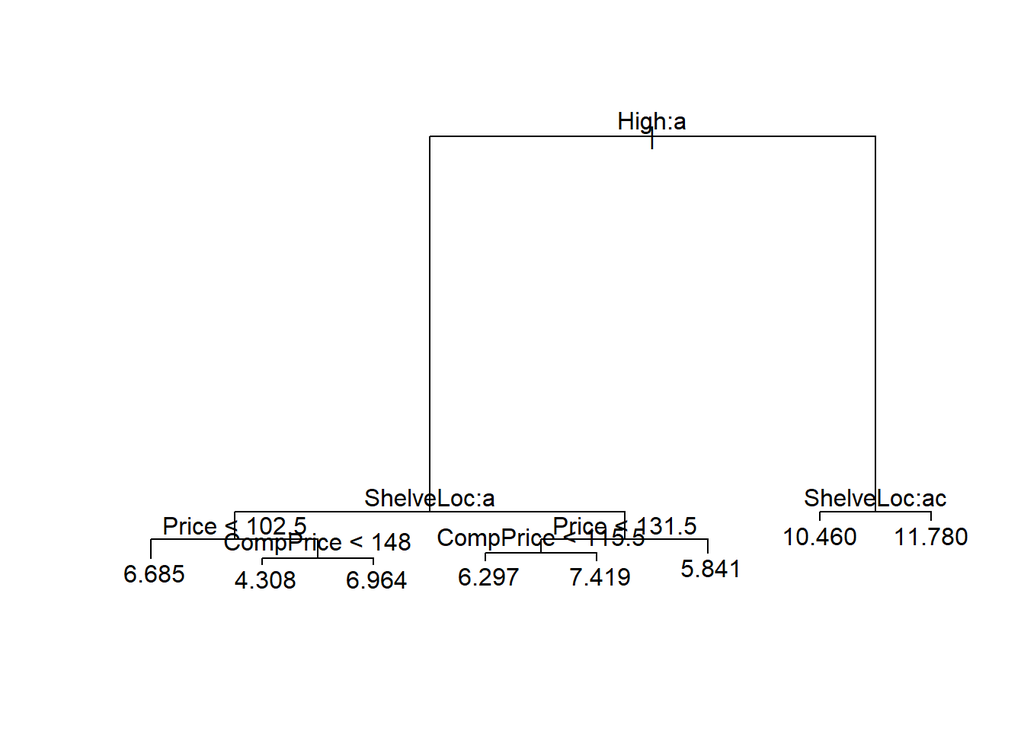

```r
plot(tree.carseats1)
text(tree.carseats1)
```

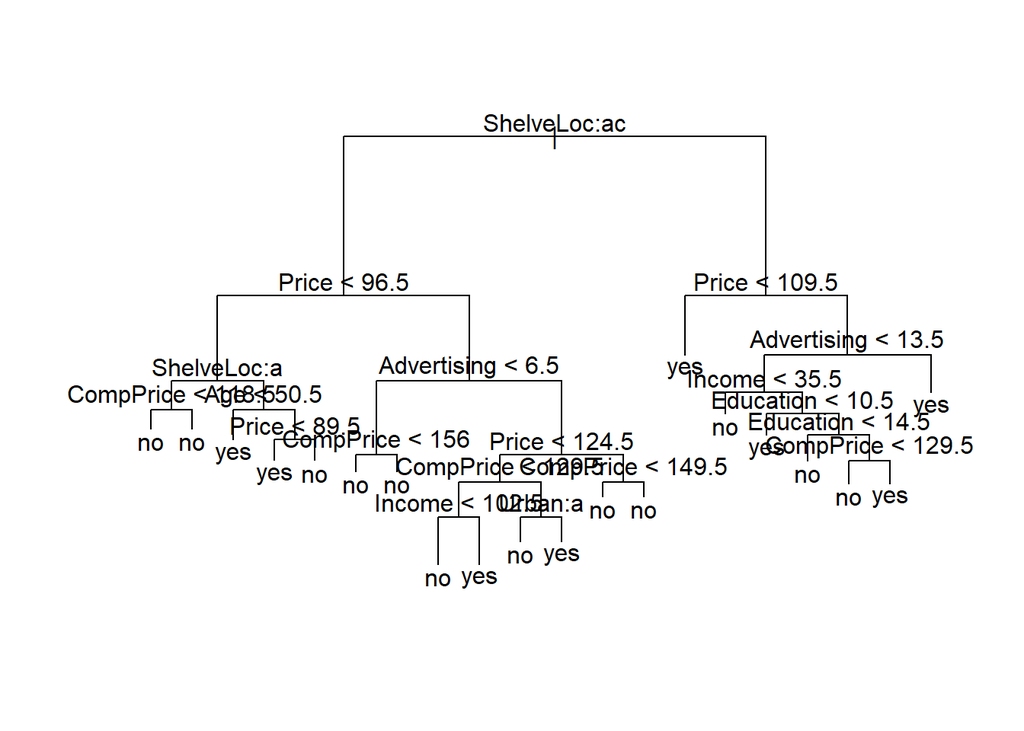

```r
plot(tree.carseats2)
text(tree.carseats2)
```

Теперь построим дерево на обучающей выборке и оценим ошибку на тестовой.

```r
set.seed(my.seed)

# обучающая выборка (50%)
train <- sample(1:nrow(Carseats), 200)

# тестовая выборка
Carseats.test <- Carseats[-train,]
High.test <- High[-train]

# строим дерево на обучающей выборке
tree.carseats2 <- tree(High ~ . -Sales, Carseats, subset = train)
tree.carseats1 <- tree(Sales ~., Carseats, subset = train)

# делаем прогноз
tree.pred1 <- predict(tree.carseats1, Carseats.test)
tree.pred2 <- predict(tree.carseats2, Carseats.test, type = "class")

#MSE
mse.test <- mean((tree.pred1 - Carseats.test$Sales)^2)
names(mse.test)[length(mse.test)] <- 'Carseats1.test.tree'
mse.test
```

```
## Carseats1.test.tree
##            3.536616
```

```r
# матрица неточностей
tbl <- table(tree.pred2, High.test)
tbl
```

```
##           High.test
## tree.pred2  no yes
##        no  131  22
##        yes  17  30
```

```r
acc.test <- sum(diag(tbl))/sum(tbl)
names(acc.test)[length(acc.test)] <- 'Carseats.class.tree.all'
acc.test
```

```
## Carseats.class.tree.all
##                   0.805
```

Обобщённая характеристика точности: доля верных прогнозов: 0.81.

# Бэггинг

```r
set.seed(my.seed)
bag.Carseats1 <- randomForest(Sales ~ ., data = Carseats, subset = train,
                           mtry = 11, importance = TRUE)
bag.Carseats1
```

```
##
## Call:
##  randomForest(formula = Sales ~ ., data = Carseats, mtry = 11,      importance = TRUE, subset = train)
##                Type of random forest: regression
##                      Number of trees: 500
## No. of variables tried at each split: 11
##
##           Mean of squared residuals: 1.922427
##                     % Var explained: 76.48
```

```r
set.seed(my.seed)
bag.Carseats2 <- randomForest(High ~ . - Sales, data = Carseats, subset = train,
                           mtry = 10, importance = TRUE)
bag.Carseats2
```

```
##
## Call:
##  randomForest(formula = High ~ . - Sales, data = Carseats, mtry = 10,      importance = TRUE, subset = train)
##                Type of random forest: classification
##                      Number of trees: 500
## No. of variables tried at each split: 10
##
##         OOB estimate of  error rate: 12%
## Confusion matrix:
##      no yes class.error
## no  144   5  0.03355705
## yes  19  32  0.37254902
```

Обобщённая характеристика точности после беггинга: доля верных прогнозов: 0.88.

# Прогнозы по моделям

## Прогноз по первой модели для непрерывного Y

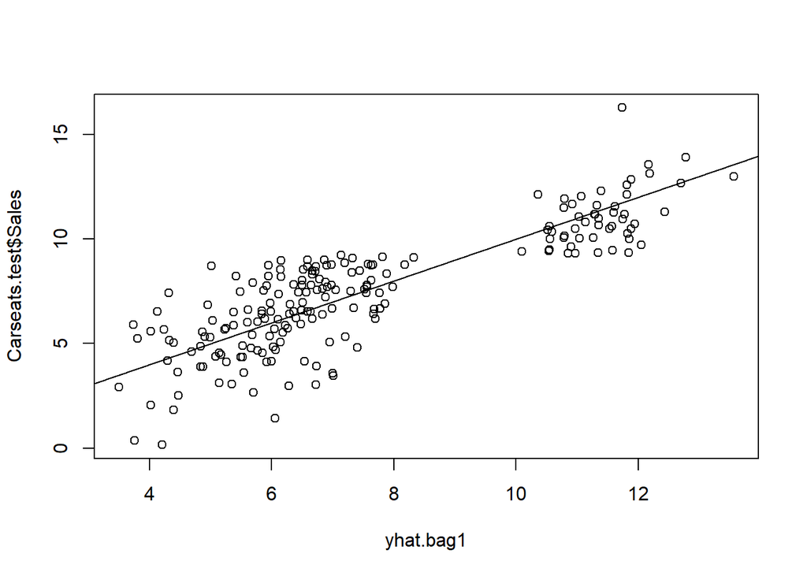

```r
# прогноз
yhat.bag1 = predict(bag.Carseats1, newdata = Carseats[-train, ])

# график "прогноз -- реализация"
plot(yhat.bag1, Carseats.test$Sales)
# линия идеального прогноза
abline(0, 1)
```

```r
# MSE на тестовой
mse.test <- mean((yhat.bag1 - Carseats.test$Sales)^2)
names(mse.test)[length(mse.test)] <- 'Carseats.bag.11'
mse.test
```

```
## Carseats.bag.11
##        2.309395
```

## Прогноз для второй модели для Категориального Y

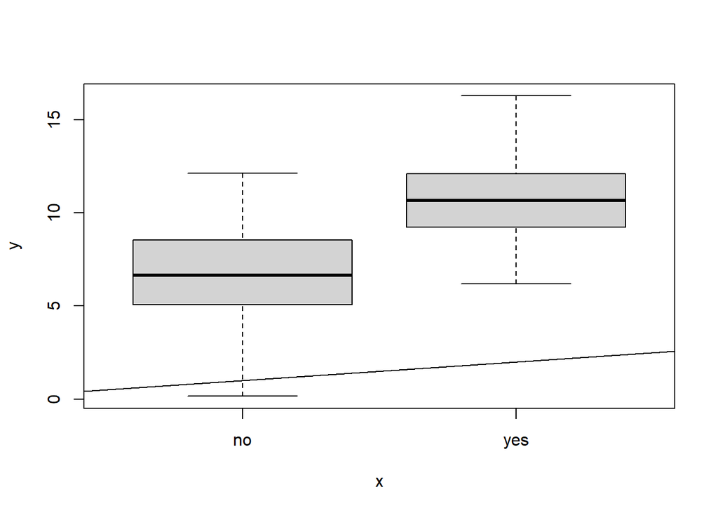

```r
# прогноз
yhat.bag2 = predict(bag.Carseats2, newdata = Carseats[-train, ])

# график "прогноз -- реализация"
plot(yhat.bag2, Carseats.test$Sales)
# линия идеального прогноза
abline(0, 1)
```

```r
bag.Carseats2
```

```
##
## Call:
##  randomForest(formula = High ~ . - Sales, data = Carseats, mtry = 10,      importance = TRUE, subset = train)
##                Type of random forest: classification
##                      Number of trees: 500
## No. of variables tried at each split: 10
##
##         OOB estimate of  error rate: 12%
## Confusion matrix:
##      no yes class.error
## no  144   5  0.03355705
## yes  19  32  0.37254902
```

Обобщённая характеристика точности после беггинга: доля верных прогнозов: 0.88